# Anotación de tipos celulares

Author

Victoria Lelis, Renata Sandoval & Ariana Silva

# Anotación de tipos celulares

### Cargar paquetes

```r
library(tidyverse)
library(patchwork)
library(Seurat)
library(SingleCellExperiment)
library(SingleR)
library(celldex)
library(DT)
library(dplyr)
library(tibble)
```

### Cargar el dataset de R396Q3k

```r
# Cargar el objeto desde el archivo RDS
R396Q3k_integrated <- readRDS("output/R396Q3_integrated.rds")

# Unir las capas del assay activo (ej. RNA)
R396Q3k_integrated <- JoinLayers(R396Q3k_integrated)

# Set the identity as louvain with resolution 0.5
sel.clust <- "RNA_snn_res.0.5"
# La identidad activa (active.ident) es la variable que Seurat usa por defecto para agrupar células en funciones como FindMarkers, DimPlot, etc.
alldata <- SetIdent(R396Q3k_integrated, value = sel.clust)

# Número de células en cada cluster
table(alldata@active.ident)
```

```
   0    1    2    3    4    5    6    7    8    9   10   11   12   13   14   15
7099 4862 4116 3432 2043 1937 1651 1622 1440 1259  772  761  658  653  555  538
  16   17   18   19   20
 490  484  361  322  228
```

Al observar el número de células por muestra, se puede apreciar que las réplicas de una misma condición (control o mutante) presentan cantidades similares entre sí, mientras que existe una diferencia notable entre condiciones.

```r
head(alldata@meta.data) ##solo queriamos ver como se veia el objeto seurat hasta este momento
```

```
                       orig.ident nCount_RNA nFeature_RNA type percent_mito
AAACCCAAGACCAAAT-1_1_1       wt_1      18564         5436 ctrl     2.343245
AAACCCAAGAGCCGAT-1_1_1       wt_1      21182         5366 ctrl     2.525729
AAACCCAAGATCCCAT-1_1_1       wt_1       1033          591 ctrl     7.357212
AAACCCACAAACGGCA-1_1_1       wt_1       2353         1439 ctrl     5.439864
AAACCCACATGAAGGC-1_1_1       wt_1      15834         4461 ctrl     1.964128
AAACCCACATGGTGGA-1_1_1       wt_1       1814         1066 ctrl     4.299890
                       percent_ribo percent_hb percent_plat
AAACCCAAGACCAAAT-1_1_1    18.185736 0.08618832  0.000000000
AAACCCAAGAGCCGAT-1_1_1    23.737135 0.03304693  0.009441979
AAACCCAAGATCCCAT-1_1_1    21.200387 0.00000000  0.000000000
AAACCCACAAACGGCA-1_1_1     8.329792 0.04249894  0.042498938
AAACCCACATGAAGGC-1_1_1    18.883415 0.00000000  0.037893141
AAACCCACATGGTGGA-1_1_1     8.324146 0.00000000  0.000000000
                       unintegrated_clusters RNA_snn_res.0.5 seurat_clusters
AAACCCAAGACCAAAT-1_1_1                     0               0               0
AAACCCAAGAGCCGAT-1_1_1                     1               1               1
AAACCCAAGATCCCAT-1_1_1                     2               2               2
AAACCCACAAACGGCA-1_1_1                    17              16              16
AAACCCACATGAAGGC-1_1_1                     7               9               9
AAACCCACATGGTGGA-1_1_1                     2               2               2
```

```r
table(alldata$orig.ident)
```

```
 mutant_1  mutant_2 mutant_31 mutant_32      wt_1      wt_2      wt_3      wt_4
     2960      3019      2100      1702      5690      7270      7009      5533
```

## Identificación de genes marcadores

Al correr `FindAllMarkers` **para cada cluster en el objeto**, devolvió una tabla con los genes marcadores de todos los clusters. Es decir, genes que se expresan más en ese cluster a diferencia de los demás.

```r
# Función: Identifica genes diferencialmente expresados entre dos grupos de células (ej. cluster 0 vs cluster 1, o cluster 0 vs todos los demás).
markers_genes <- FindAllMarkers(
    alldata,
    log2FC.threshold = 0.2, #  umbral de cambio de expresión (default 0.25).
    test.use = "wilcox", # método estadístico (ej. "wilcox", "MAST", "DESeq2").
    min.pct = 0.1, # porcentaje mínimo de células que deben expresar el gen.
    # Exige que la diferencia en la proporción de células que expresan un gen entre el grupo de interés y el grupo de referencia sea al menos del 20%.
    min.diff.pct = 0.2,
    only.pos = TRUE, # si TRUE, devuelve solo genes sobreexpresados.
    max.cells.per.ident = 50, # Limita el número máximo de células usadas por cluster (ident) en el test de DE.
    assay = "RNA"
)
markers_genes  %>%
  # Agrupa la tabla de genes marcadores por el cluster al que pertenecen.
    group_by(cluster) %>%
  #  log2 fold change promedio sea mayor que 1.
    dplyr::filter(avg_log2FC > 1) %>%
  # Convertir en tabla
  DT::datatable()
```

|  | p_val | avg_log2FC | pct.1 | pct.2 | p_val_adj | cluster | gene |
| --- | --- | --- | --- | --- | --- | --- | --- |
| 1 | 2.927691808649836e-08 | 1.186158620299738 | 0.799 | 0.405 | 0.0009452053004225996 | 0 | Myct1 |
| 2 | 6.582353321031103e-06 | 1.147036585819893 | 0.989 | 0.544 | 0.2125112769694892 | 0 | Prkg1 |
| 3 | 6.753353077344837e-06 | 1.119363872752698 | 0.946 | 0.491 | 0.218032004102078 | 0 | Samd12 |
| 4 | 7.362671001138559e-06 | 1.000164895682894 | 0.868 | 0.5 | 0.2377038332717584 | 0 | Spns2 |
| 5 | 9.96186463364532e-06 | 1.080834231853796 | 0.595 | 0.245 | 0.3216187996972392 | 0 | Slc18a2 |
| 6 | 1.721923115982082e-05 | 1.239472301950496 | 0.817 | 0.376 | 0.5559228779948151 | 0 | Trpc6 |
| 7 | 2.120311670474123e-05 | 1.088452237657874 | 0.998 | 0.629 | 0.6845426228125706 | 0 | Hlf |
| 8 | 5.182578527194816e-05 | 1.351004721831614 | 0.746 | 0.299 | 1 | 0 | Mpl |
| 9 | 5.654013431034609e-05 | 1.260117171053649 | 0.538 | 0.197 | 1 | 0 | Pdzk1ip1 |
| 10 | 6.05605877239457e-05 | 1.436558091968001 | 0.516 | 0.214 | 1 | 0 | Krt18 |

[output cut: 5221 more lines]

```r
write.csv(markers_genes, "output/cluster_markers.csv", row.names = FALSE)
```

Revisando el número de células en cada cluster se verificó que a excepción de los útimos dos clústers, todas podrían considerarse clusters grandes por lo que se conservara la prueba wilcoxon.

**Important**

## Genes marcadores

Se seleccionaron los 25 genes más sobreexpresados para representarlos gráficamente.

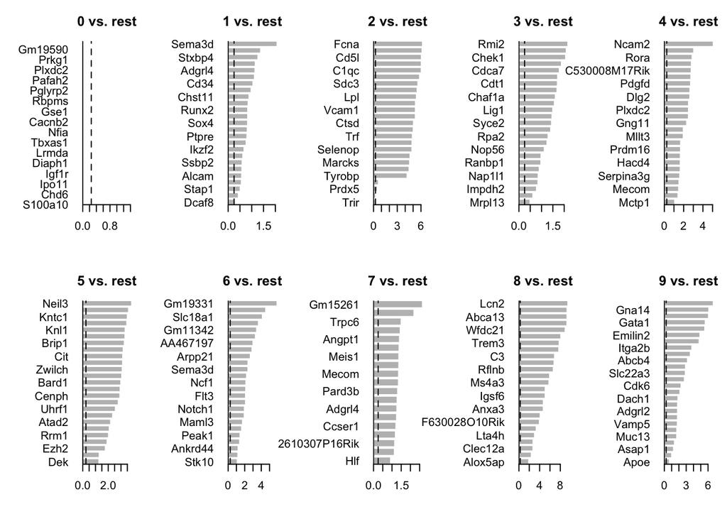

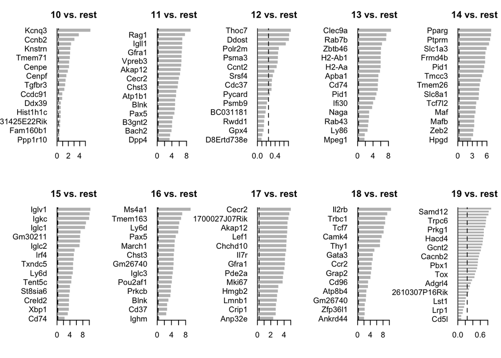

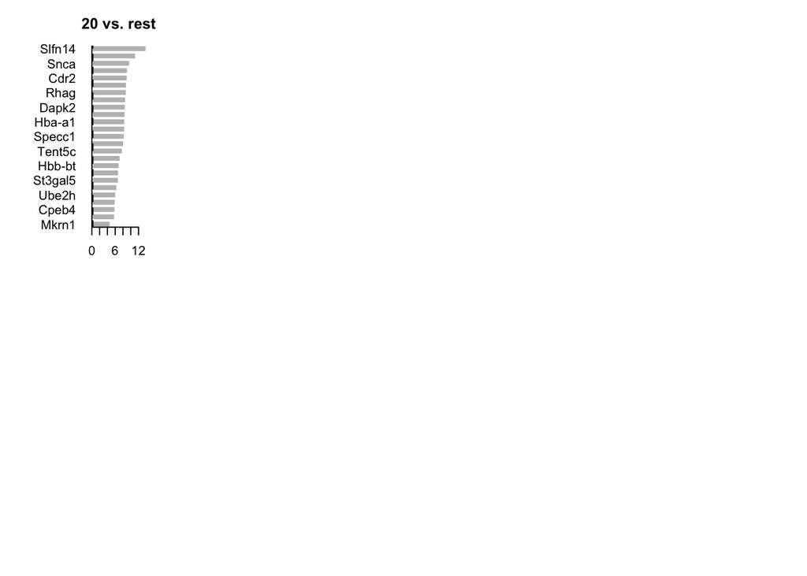

```r
top25 <- markers_genes %>%
    group_by(cluster) %>%
    top_n(-25, p_val_adj)

# Divide la ventana gráfica en una cuadrícula de 2 filas × 5 columnas, para mostrar hasta 10 gráficos en la misma figura.
par(mfrow = c(2, 5), mar = c(4, 6, 3, 1))
# for para los clusters
for (i in unique(top25$cluster)) {
    barplot(sort(setNames(top25$avg_log2FC, top25$gene)[top25$cluster == i], F),
        horiz = T, las = 1, main = paste0(i, " vs. rest"), border = "white", yaxs = "i"
    )
    abline(v = c(0, 0.25), lty = c(1, 2))
}
```

### Heatmap

```r
top5 <- markers_genes %>%
    group_by(cluster) %>%
  # Selecciona las 5 filas con el valor más pequeño de p_val_adj dentro de cada grupo.
    slice_min(p_val_adj, n = 5, with_ties = FALSE)

# crear una ranura «scale.data» para los genes seleccionados
alldata_top5 <- ScaleData(alldata, features = as.character(unique(top5$gene)), assay = "RNA")
# save
# saveRDS(alldata_top5, file = "output/alldata_top5.rds")
# saveRDS(top5, file = "output/top5.rds")
##Viendo los nombres de los genes marcadores top 5
top5
```

```
# A tibble: 105 × 7
# Groups:   cluster [21]
           p_val avg_log2FC pct.1 pct.2 p_val_adj cluster gene
           <dbl>      <dbl> <dbl> <dbl>     <dbl> <fct>   <chr>
 1 0.0000000293       1.19  0.799 0.405 0.000945  0       Myct1
 2 0.000000585        0.859 0.973 0.671 0.0189    0       Sgms1
 3 0.000000919        0.852 0.702 0.362 0.0297    0       Adam22
 4 0.00000658         1.15  0.989 0.544 0.213     0       Prkg1
 5 0.00000675         1.12  0.946 0.491 0.218     0       Samd12
 6 0.00000000272      1.38  0.992 0.55  0.0000878 1       Flt3
 7 0.00000000538      1.14  1     0.713 0.000174  1       Adgrl4
 8 0.0000000711       0.307 0.902 0.678 0.00230   1       Dcaf8
 9 0.0000000753       1.05  0.988 0.599 0.00243   1       Cd34
10 0.000000102        0.830 0.999 0.688 0.00330   1       Gcnt2
# ℹ 95 more rows
```

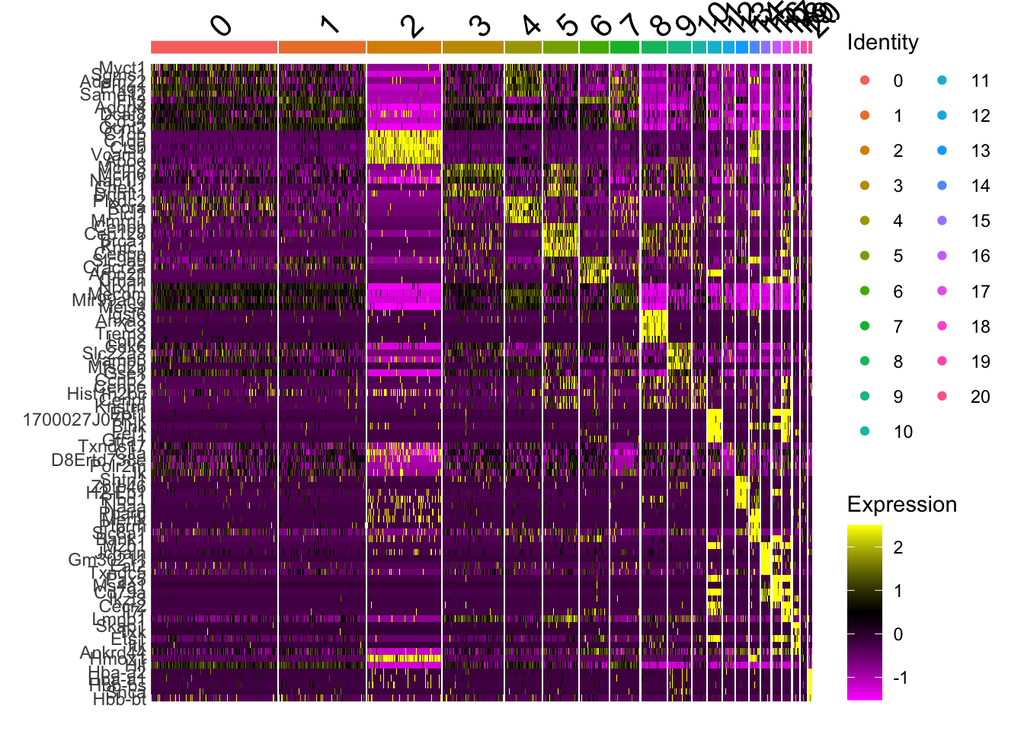

```r
# Visualizacion grafica
DoHeatmap(alldata_top5, features = as.character(unique(top5$gene)), group.by = sel.clust, assay = "RNA")
```

### Dotplot

Al igual que el heatmap, el dotplot permite visualizar los patrones de expresión de los genes marcadores en los distintos clusters, por lo que aporta información consistente con la discutida previamente. En general, se observan los mismos perfiles de expresión característicos de cada cluster y las similitudes entre algunos grupos celulares.

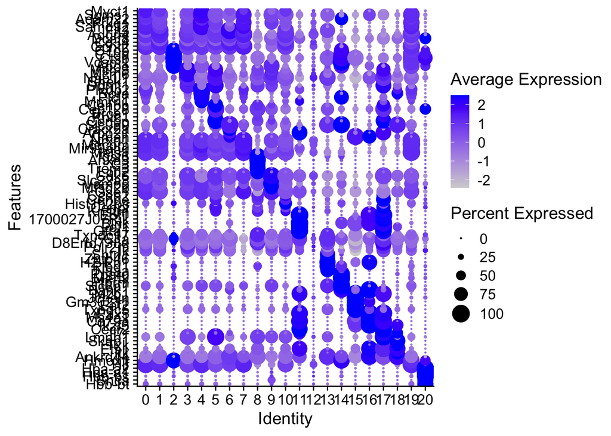

```r
DotPlot(alldata_top5, features = rev(as.character(unique(top5$gene))), group.by = sel.clust, assay = "RNA") + coord_flip()
```

### Violin plot

También puede trazarse un gráfico de violín para cada gen.

[figure not shown]

```r
top3 <- markers_genes %>%
    group_by(cluster) %>%
    slice_min(order_by = p_val_adj, n = 3, with_ties = FALSE)
# saveRDS(top3, file = "output/top3.rds")

# Establece pt.size en cero si no quieres que todos los puntos oculten las formas del violín, o en un valor pequeño, como 0,1
VlnPlot(alldata_top5, features = as.character(unique(top3$gene)), ncol = 5, group.by = sel.clust, assay = "RNA", pt.size = 0)
```

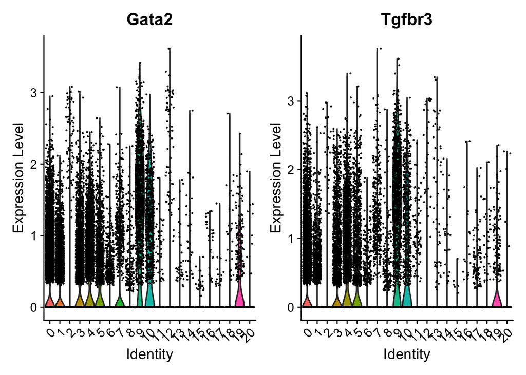

```r
VlnPlot(alldata_top5, features = c("Gata2", "Tgfbr3"))
```

**Violin plots por condición:**

Se puede observar una clara diferencia en el nivel de expresión de estos genes entre algunos clusters según la condición analizada. Sin embargo, en ambos casos las células mutantes presentan una mayor expresión del gen en comparación con las células control.

```
The default behaviour of split.by has changed.
Separate violin plots are now plotted side-by-side.
To restore the old behaviour of a single split violin,
set split.plot = TRUE.

This message will be shown once per session.
```

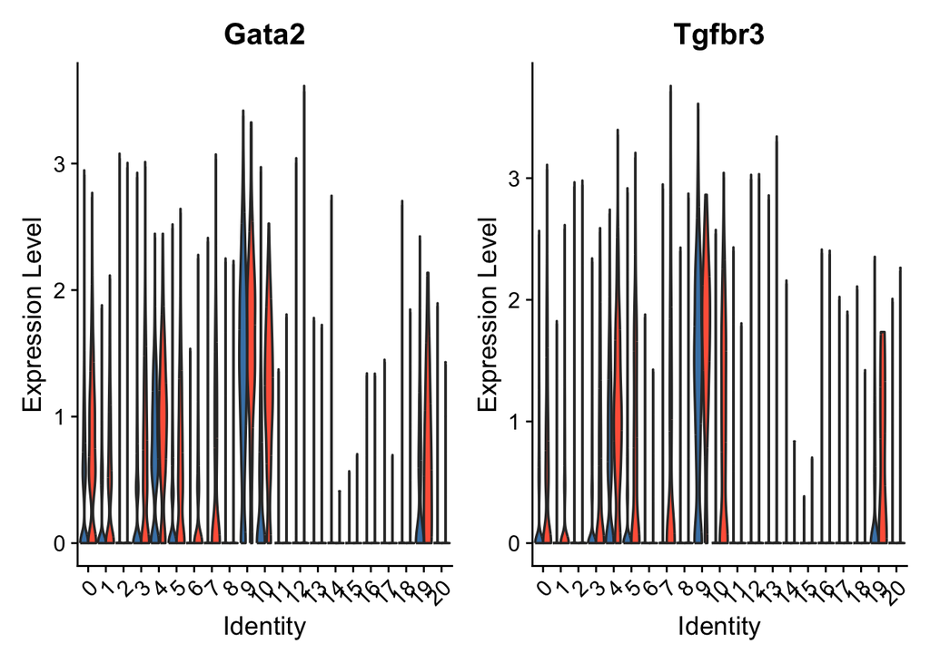

```r
VlnPlot(alldata_top5,
        features = c("Gata2", "Tgfbr3"),
        split.by = "type",
        cols = c("ctrl" = "steelblue", "mutant" = "tomato"),
        pt.size = 0)
```

### **Gradientes** en UMAP

Cada gen se proyecta como un mapa de calor sobre las coordenadas del UMAP, mostrando en qué regiones (clusters) se expresa más o menos.

Estos son genes de interés que son importantes en el contexto de las células hematopoyécticas de acuerdo al artículo:

- *Gata2*: factor de transcripción esencial para HSC; sobreexpresado en varios clústers de progenitores Gata2 R396Q/+
- *Tgfbr3*: correceptor de TGFβ; altamente sobreexpresado en progenitores mutantes, asociado al sesgo mieloide
- *Ly6c1*: marcador de poblaciones granulocíticas/monocíticas; expresado exclusivamente en progenitores Gata2R396Q/+
- *Slamf1* (CD150): marcador de LT-HSC; aumentado en mutantes, asociado a envejecimiento acelerado de HSC

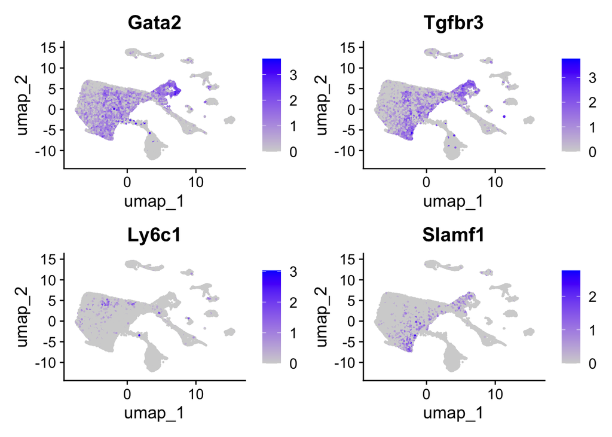

```r
FeaturePlot(alldata_top5,
            features = c("Gata2", "Tgfbr3", "Ly6c1", "Slamf1"),
            ncol = 2)
```

## **Asignar identidad celular a los clusters (**`SingleR` **+** `celldex`**)**

```r
#Liberacion de memoria
rm(list = setdiff(ls(), "R396Q3k_integrated"))
```

```r
# convertir de objeto seurat a SingleCellExperiment
sce <- as.SingleCellExperiment(R396Q3k_integrated)
sce
```

```
class: SingleCellExperiment
dim: 32285 35283
metadata(0):
assays(2): counts logcounts
rownames(32285): Xkr4 Gm1992 ... AC234645.1 AC149090.1
rowData names(0):
colnames(35283): AAACCCAAGACCAAAT-1_1_1 AAACCCAAGAGCCGAT-1_1_1 ...
  TTTGGAGTCTTAGGAC-1_4_2 TTTGGTTCAGCCGGTT-1_4_2
colData names(12): orig.ident nCount_RNA ... seurat_clusters ident
```

```
reducedDimNames(3): PCA UMAP HARMONY
mainExpName: RNA
```

```
altExpNames(0):
```

```r
# saveRDS(sce, file = "output/sce.rds")
```

Se utilizará un paquete llamado `SingleR` para etiquetar cada célula. `SingleR` utiliza un conjunto de datos de referencia de tipos celulares con datos de expresión para deducir la mejor etiqueta para cada célula. El paquete `celldex` contiene una práctica recopilación de referencias de tipos celulares que, actualmente, incluye los siguientes conjuntos:

```r
library(celldex)
ls('package:celldex')
```

```
 [1] "BlueprintEncodeData"              "DatabaseImmuneCellExpressionData"
 [3] "defineTextQuery"                  "fetchLatestVersion"
 [5] "fetchMetadata"                    "fetchReference"
 [7] "HumanPrimaryCellAtlasData"        "ImmGenData"
 [9] "listReferences"                   "listVersions"
[11] "MonacoImmuneData"                 "MouseRNAseqData"
[13] "NovershternHematopoieticData"     "saveReference"
[15] "searchReferences"                 "surveyReferences"
```

En este proyecto, se usará el conjunto de datos de ratón.

```r
# descargar referencia de ratoncito
ref.set <- celldex::MouseRNAseqData()
```

Observación de etiquetas (labels)

```r
unique(ref.set$label.main)
```

```
 [1] "Adipocytes"        "Neurons"           "Astrocytes"
 [4] "Endothelial cells" "Erythrocytes"      "Fibroblasts"
 [7] "Granulocytes"      "Macrophages"       "Microglia"
[10] "Monocytes"         "NK cells"          "Oligodendrocytes"
[13] "T cells"           "Dendritic cells"   "Cardiomyocytes"
[16] "Hepatocytes"       "B cells"           "Epithelial cells"
```

Un ejemplo de los tipos de etiquetas «finas».

```r
head(unique(ref.set$label.fine))
```

```
[1] "Adipocytes"           "aNSCs"                "Astrocytes"
[4] "Astrocytes activated" "Endothelial cells"    "Erythrocytes"
```

Ahora, se etiquetarán las células utilizando el objeto `SingleCellExperiment`, con la referencia establecida anteriormente.

```r
pred.cnts <- SingleR::SingleR(test = sce, ref = ref.set, labels = ref.set$label.main)
```

Se conservan los tipos que tengan más de 10 celdas en la etiqueta, se vuelve a asignar esas etiquetas al objeto Seurat y se visualizan en umap.

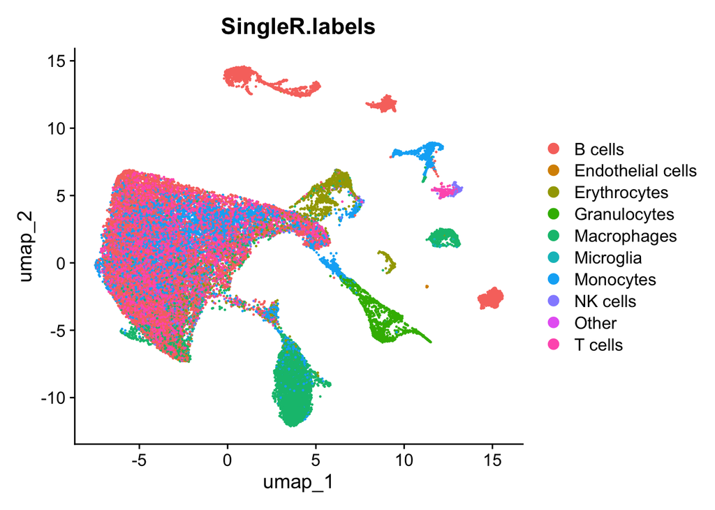

```r
lbls.keep <- table(pred.cnts$labels)>10
R396Q3k_integrated$SingleR.labels <- ifelse(lbls.keep[pred.cnts$labels], pred.cnts$labels, 'Other')
# Crear R396Q3k_annotated para que el Paso 5 funcione
R396Q3k_annotated <- R396Q3k_integrated  # <- AGREGAR ESTA LÍNEA
DimPlot(R396Q3k_integrated, reduction='umap', group.by='SingleR.labels')
```

Los tipos celulares asignados por SingleR son coherentes con el contexto biológico del análisis, ya que las células hematopoyéticas se diferencian en dos grandes linajes: linfoide (células T, B y NK) y mieloide (monocitos, macrófagos y granulocitos). Sin embargo, también se identificaron algunos tipos celulares menos esperados, como microglia y células endoteliales, lo que probablemente podría ser una anotación incorrecta debido a la similitud en el perfil de expresión génica con otros tipos de poblaciones celulares.

Al observar los gradientes de expresión en el UMAP, se puede identificar la sobreexpresión de estos genes en subpoblaciones celulares específicas. En especial *Gata2* y *Tgfbr3*, cuya expresión elevada parece concentrarse en las mismas regiones del UMAP.

## Marcadores conservados de tipos celulares

Para identificar **marcadores conservados de tipos celulares** en Seurat, se usa la función `FindConservedMarkers()`. Esta función busca genes que estén diferencialmente expresados en un cluster específico **y que además sean consistentes entre condiciones o grupos**. Aquí se analizarán los marcadores conservados del clúster cero para ejemplificación. La elección de este clúster es por su tamaño, siendo el más grande de todos, con más de 6 mil células.

```r
# Buscar marcadores conservados en el cluster 0
conserved_markers <- FindConservedMarkers(
  R396Q3k_annotated,
  ident.1 = 0,              # cluster de interés
  grouping.var = "type",  # variable que define los grupos (ej. donantes)
  assay = "RNA"
)
```

```
Testing group mtnt: (0) vs (2, 6, 13, 4, 5, 8, 1, 15, 10, 3, 9, 7, 11, 16, 12, 20, 17, 18, 14, 19)
```

```
Testing group ctrl: (0) vs (1, 2, 16, 9, 17, 10, 7, 3, 15, 5, 12, 8, 18, 11, 19, 4, 6, 14, 20, 13)
```

```r
head(conserved_markers)
```

```
          mtnt_p_val mtnt_avg_log2FC mtnt_pct.1 mtnt_pct.2 mtnt_p_val_adj
Prkg1   0.000000e+00       1.1731498      0.989      0.598   0.000000e+00
Hlf     0.000000e+00       1.1089546      0.998      0.675   0.000000e+00
Nrxn1  2.296495e-315       1.0307166      0.999      0.717  7.414235e-311
Samd12 3.795084e-315       1.1999002      0.943      0.517  1.225243e-310
Angpt1 5.885235e-301       1.0534518      0.999      0.753  1.900048e-296
Ifitm1 7.970443e-300       0.9698194      0.992      0.712  2.573258e-295
       ctrl_p_val ctrl_avg_log2FC ctrl_pct.1 ctrl_pct.2 ctrl_p_val_adj
Prkg1           0       1.1374468      0.989      0.524              0
Hlf             0       1.0839945      0.998      0.611              0
Nrxn1           0       0.9481894      0.997      0.649              0
Samd12          0       1.0923673      0.947      0.481              0
Angpt1          0       1.0800390      1.000      0.667              0
Ifitm1          0       1.2417661      0.989      0.598              0
            max_pval minimump_p_val
Prkg1   0.000000e+00              0
Hlf     0.000000e+00              0
Nrxn1  2.296495e-315              0
Samd12 3.795084e-315              0
Angpt1 5.885235e-301              0
Ifitm1 7.970443e-300              0
```

### Seleccionar los más relevantes

- Para encontrar **marcadores conservados**, lo más lógico es ordenar por `max_pval`:
  - Si el máximo p‑valor sigue siendo bajo, significa que el gen es significativo en todos los grupos.
- `minimump_p_val` solo te dice el mejor grupo, pero no garantiza conservación.

```r
top_conserved <- conserved_markers %>%
  rownames_to_column("gene") %>%
  arrange(max_pval) %>% # ordenar de menor a mayor
  slice_head(n = 20) # tomar los 10 más robustos

head(top_conserved)
```

```
    gene    mtnt_p_val mtnt_avg_log2FC mtnt_pct.1 mtnt_pct.2 mtnt_p_val_adj
1  Prkg1  0.000000e+00       1.1731498      0.989      0.598   0.000000e+00
2    Hlf  0.000000e+00       1.1089546      0.998      0.675   0.000000e+00
3  Nrxn1 2.296495e-315       1.0307166      0.999      0.717  7.414235e-311
4 Samd12 3.795084e-315       1.1999002      0.943      0.517  1.225243e-310
5 Angpt1 5.885235e-301       1.0534518      0.999      0.753  1.900048e-296
6 Ifitm1 7.970443e-300       0.9698194      0.992      0.712  2.573258e-295
  ctrl_p_val ctrl_avg_log2FC ctrl_pct.1 ctrl_pct.2 ctrl_p_val_adj      max_pval
1          0       1.1374468      0.989      0.524              0  0.000000e+00
2          0       1.0839945      0.998      0.611              0  0.000000e+00
3          0       0.9481894      0.997      0.649              0 2.296495e-315
4          0       1.0923673      0.947      0.481              0 3.795084e-315
5          0       1.0800390      1.000      0.667              0 5.885235e-301
6          0       1.2417661      0.989      0.598              0 7.970443e-300
  minimump_p_val
1              0
2              0
3              0
4              0
5              0
6              0
```

### Visualización

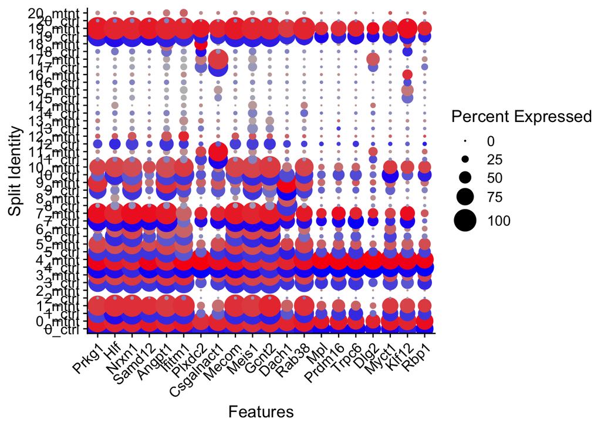

```r
DotPlot(R396Q3k_annotated, features = top_conserved$gene, cols = c("blue", "red"), dot.scale = 8, split.by = "type") +
    RotatedAxis()
```

### Interpretación 🔎

- Si un gen aparece con puntos grandes y coloreados en ambos grupos (R396Q y control), significa que es un **marcador conservado**, es decir, se expresa de manera robusta en ese cluster sin importar la condición.
- Si el color o el tamaño cambia mucho entre células R396Q y control, ese gen podría ser un **marcador diferencial** entre condiciones.

## Guardar dataset y liberación de memoria

```r
saveRDS(R396Q3k_annotated, file = "output/R396Q3_annotated.rds")
cat("\n--- Liberando memoria ---\n")

rm(list = ls())

gc()
```